# Vignette - Conjunctive Screening in Models of Multiple Discreteness

Nino Hardt

## Conjunctive Screening in Models of Multiple Discreteness

## Packages and functions

The `echoice2` package is available from github. In some version of `install_github`, warnings are converted to errors, which might prevent succesfull installation. Setting the corresponding environment variable to true will resolve the issue.

```r
  Sys.setenv("R_REMOTES_NO_ERRORS_FROM_WARNINGS" = "true")
  remotes::install_github("ninohardt/echoice2")
```

Once installed, load packages `echoice2` and `tidyverse`:

```r
  suppressPackageStartupMessages(library(tidyverse))
  library(echoice2)
```

## Data

Choice data should be provided in a `long’ format, i.e. one row per alternative, choice task and respondent.

```r
  load('data/pizza_long.rdata')
```

### Holdout

For hold-out validation, we keep 1 task per respondent. In v-fold cross-validation, this is done several times. However, each re-run of the model may take a while. For this example, we only use 1 set of holdout tasks. Hold-out tasks shown in this vignette may be different from those shown in the paper - however, the superiority of the proposed model should hold.

```r
set.seed(1.2335252)
    pizza_ho_tasks=
    pizza_long %>%
      distinct(id,task) %>%
      mutate(id=as.integer(id))%>%
      group_by(id) %>%
      summarise(task=sample(task,1))
  set.seed(NULL)


    pizza_cal= pizza_long %>% mutate(id=as.integer(id)) %>%
      anti_join(pizza_ho_tasks, by=c('id','task'))

    pizza_ho= pizza_long %>% mutate(id=as.integer(id)) %>%
      semi_join(pizza_ho_tasks, by=c('id','task'))
```

## Estimation

Estimate both models using 1M draws.

```r
  #compensatory
  out_pizza_cal = pizza_cal %>% vd_est_vdmn(R=1000000, keep=50)
  save(out_pizza_cal,file='draws/out_pizza_cal.rdata')

  #conjunctive screening
  out_pizza_screening_cal = pizza_cal %>% vd_est_vdm_screenpr(R=1000000, keep=50)
  save(out_pizza_screening_cal,file='draws/out_pizza_screening_cal.rdata')
```

I draws have already been saved, no beed to re-run estimation.

```r
  load('draws/out_pizza_cal.rdata')
  load('draws/out_pizza_screening_cal.rdata')

  out_pizza_cal_            = vd_thin_draw(out_pizza_cal, .2, 5000)
  out_pizza_screening_cal_  = vd_thin_draw(out_pizza_screening_cal, .4, 5000)
```

### Diagnostics

Quick check of convergence.

Compensatory:

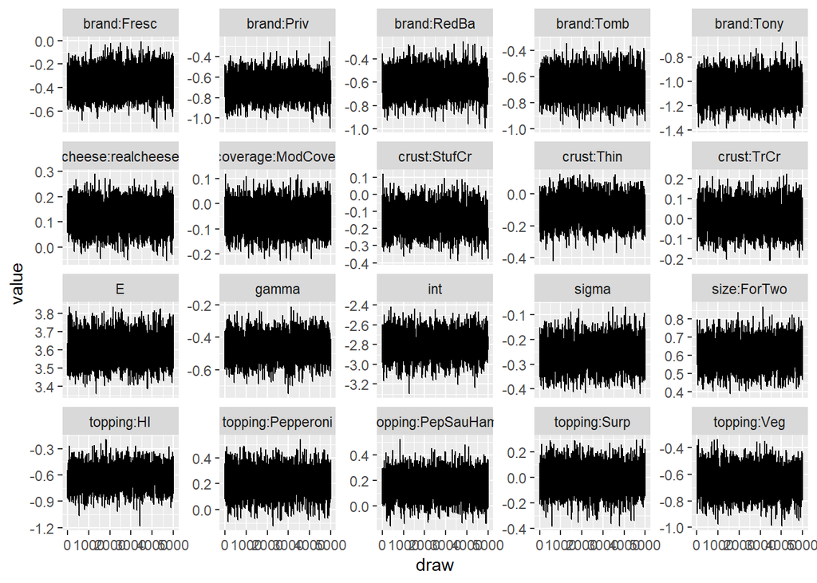

```r
  out_pizza_cal_ %>% ec_trace_MU(burnin = 100)
```

Conjunctive Screening:

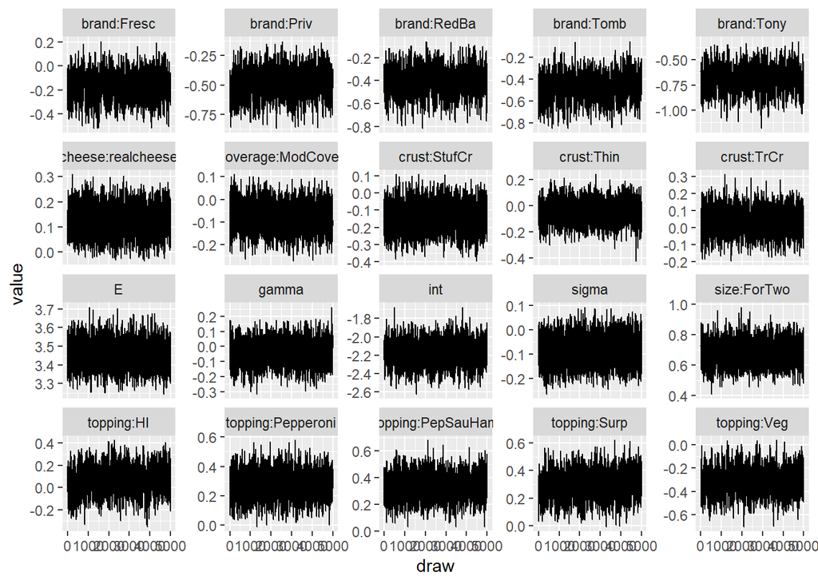

```r
  out_pizza_screening_cal_ %>% ec_trace_MU(burnin = 100)
```

## Fit

### In-sample (LMD)

First, we compare in-sample fit. The proposed model fits a lot better.

```r
  list(compensatory=out_pizza_cal_,
       conjunctive=out_pizza_screening_cal_) %>%
    map_dfr(ec_lmd_NR, .id = 'model') %>%
    filter(part==1) %>% select(-part)
```

```
## # A tibble: 2 x 2
##   model           lmd
##   <chr>         <dbl>
## 1 compensatory -8368.
## 2 conjunctive  -7851.
```

### Holdout (MAE,…)

Now, we compare out of sample fit. For illustration purposes, only one fold is used for holdout fit. Moreover, only 5000 draws and 5000 simulated error terms are used.

```r
seeed=5959

#generate predictions
ho_dem_vd=
    pizza_ho %>%
      prep_newprediction(pizza_cal) %>%
        vd_dem_vdmn(out_pizza_cal_,
                    ec_gen_err_normal(pizza_ho, out_pizza_cal_, seed=seeed))
```

```
## Using 16 cores
```

```
##  Computation in progress
```

```r
ho_dem_vdsrpr=
    pizza_ho %>%
      prep_newprediction(pizza_cal) %>%
        vd_dem_vdmsrpr(out_pizza_screening_cal_,
                       ec_gen_err_normal(pizza_ho, out_pizza_screening_cal_, seed=seeed))
```

```
## Using 16 cores
```

```
##  Computation in progress
```

```r
#evaluate
    list(compensatory=ho_dem_vd,
       conjunctive=ho_dem_vdsrpr) %>%
    map_dfr(.%>%
      vd_dem_summarise() %>% select(id:cheese, .pred=`E(demand)`) %>%
      mutate(pmMSE=(x-.pred)^2,
             pmMAE=abs(x-.pred),
             pmbias=.pred-x) %>%
      summarise(MSE=mean(pmMSE),
                MAE=mean(pmMAE),
                bias=mean(pmbias)),
    .id = 'model')
```

```
## # A tibble: 2 x 4
##   model          MSE   MAE  bias
##   <chr>        <dbl> <dbl> <dbl>
## 1 compensatory  1.36 0.585 0.105
## 2 conjunctive   1.23 0.552 0.118
```

## Estimates

### Part-Worths

```r
out_pizza_cal %>% ec_estimates_MU()
```

```
## # A tibble: 20 x 12
##    attribute lvl       par       mean     sd  `CI-5%` `CI-95%` sig   model error
##    <chr>     <chr>     <chr>    <dbl>  <dbl>    <dbl>    <dbl> <lgl> <chr> <chr>
##  1 <NA>      <NA>      int   -2.79    0.124  -2.99     -2.60   TRUE  VD-c~ Norm~
##  2 brand     Fresc     bran~ -0.351   0.0976 -0.514    -0.191  TRUE  VD-c~ Norm~
##  3 brand     Priv      bran~ -0.686   0.101  -0.853    -0.524  TRUE  VD-c~ Norm~
##  4 brand     RedBa     bran~ -0.603   0.0991 -0.766    -0.441  TRUE  VD-c~ Norm~
##  5 brand     Tomb      bran~ -0.664   0.0938 -0.821    -0.513  TRUE  VD-c~ Norm~
##  6 brand     Tony      bran~ -1.05    0.0998 -1.21     -0.891  TRUE  VD-c~ Norm~
##  7 size      ForTwo    size~  0.605   0.0679  0.496     0.717  TRUE  VD-c~ Norm~
##  8 crust     StufCr    crus~ -0.142   0.0693 -0.256    -0.0282 TRUE  VD-c~ Norm~
##  9 crust     Thin      crus~ -0.102   0.0730 -0.222     0.0174 FALSE VD-c~ Norm~
## 10 crust     TrCr      crus~  0.00902 0.0624 -0.0935    0.112  FALSE VD-c~ Norm~
## 11 topping   HI        topp~ -0.628   0.115  -0.819    -0.440  TRUE  VD-c~ Norm~
## 12 topping   Pepperoni topp~  0.208   0.0902  0.0603    0.356  TRUE  VD-c~ Norm~
## 13 topping   PepSauHam topp~  0.153   0.0905  0.00340   0.301  TRUE  VD-c~ Norm~
## 14 topping   Surp      topp~ -0.0123  0.0947 -0.170     0.143  FALSE VD-c~ Norm~
## 15 topping   Veg       topp~ -0.655   0.0933 -0.810    -0.502  TRUE  VD-c~ Norm~
## 16 coverage  ModCover  cove~ -0.0540  0.0499 -0.136     0.0273 FALSE VD-c~ Norm~
## 17 cheese    realchee~ chee~  0.120   0.0501  0.0394    0.202  TRUE  VD-c~ Norm~
## 18 <NA>      <NA>      sigma -0.255   0.0537 -0.340    -0.170  TRUE  VD-c~ Norm~
## 19 <NA>      <NA>      gamma -0.460   0.0695 -0.573    -0.347  TRUE  VD-c~ Norm~
## 20 <NA>      <NA>      E      3.61    0.0706  3.49      3.72   TRUE  VD-c~ Norm~
## # ... with 2 more variables: reference_lvl <chr>, parameter <chr>
```

```r
out_pizza_screening_cal %>% ec_estimates_MU()
```

```
## # A tibble: 20 x 12
##    attribute lvl        par       mean     sd `CI-5%` `CI-95%` sig   model error
##    <chr>     <chr>      <chr>    <dbl>  <dbl>   <dbl>    <dbl> <lgl> <chr> <chr>
##  1 <NA>      <NA>       int    -2.17   0.135  -2.39   -1.96    TRUE  VD-c~ Norm~
##  2 brand     Fresc      brand~ -0.167  0.107  -0.348   0.00464 FALSE VD-c~ Norm~
##  3 brand     Priv       brand~ -0.472  0.114  -0.663  -0.289   TRUE  VD-c~ Norm~
##  4 brand     RedBa      brand~ -0.404  0.112  -0.592  -0.226   TRUE  VD-c~ Norm~
##  5 brand     Tomb       brand~ -0.480  0.112  -0.667  -0.299   TRUE  VD-c~ Norm~
##  6 brand     Tony       brand~ -0.693  0.122  -0.894  -0.497   TRUE  VD-c~ Norm~
##  7 size      ForTwo     size:~  0.679  0.0742  0.560   0.798   TRUE  VD-c~ Norm~
##  8 crust     StufCr     crust~ -0.140  0.0779 -0.270  -0.0142  TRUE  VD-c~ Norm~
##  9 crust     Thin       crust~ -0.0559 0.0788 -0.184   0.0749  FALSE VD-c~ Norm~
## 10 crust     TrCr       crust~  0.0354 0.0683 -0.0767  0.148   FALSE VD-c~ Norm~
## 11 topping   HI         toppi~  0.0639 0.115  -0.123   0.252   FALSE VD-c~ Norm~
## 12 topping   Pepperoni  toppi~  0.276  0.0864  0.134   0.418   TRUE  VD-c~ Norm~
## 13 topping   PepSauHam  toppi~  0.336  0.0890  0.191   0.481   TRUE  VD-c~ Norm~
## 14 topping   Surp       toppi~  0.297  0.0908  0.145   0.444   TRUE  VD-c~ Norm~
## 15 topping   Veg        toppi~ -0.319  0.108  -0.496  -0.139   TRUE  VD-c~ Norm~
## 16 coverage  ModCover   cover~ -0.0764 0.0559 -0.168   0.0148  FALSE VD-c~ Norm~
## 17 cheese    realcheese chees~  0.126  0.0541  0.0372  0.216   TRUE  VD-c~ Norm~
## 18 <NA>      <NA>       sigma  -0.0881 0.0556 -0.180   0.00262 FALSE VD-c~ Norm~
## 19 <NA>      <NA>       gamma  -0.0444 0.0760 -0.171   0.0773  FALSE VD-c~ Norm~
## 20 <NA>      <NA>       E       3.46   0.0681  3.35    3.57    TRUE  VD-c~ Norm~
## # ... with 2 more variables: reference_lvl <chr>, parameter <chr>
```

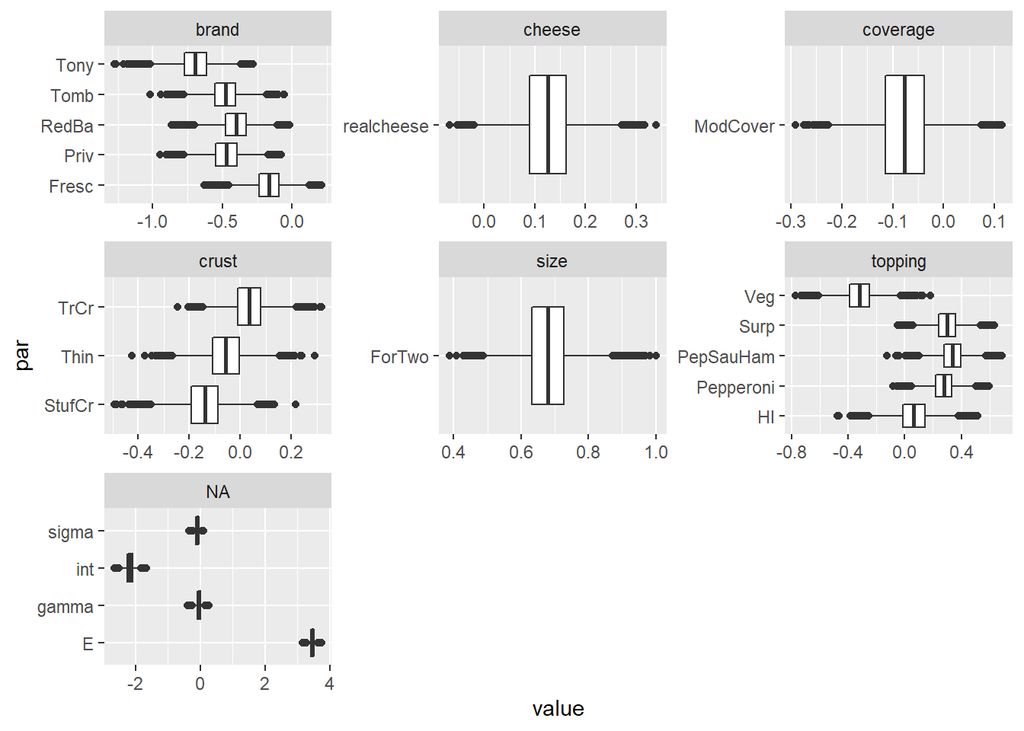

```r
out_pizza_screening_cal %>% ec_boxplot_MU()
```

### Screening probabilities

```r
out_pizza_screening_cal %>% ec_estimates_screen()
```

```
## # A tibble: 22 x 8
##    attribute lvl        par                 mean     sd `CI-5%` `CI-95%`   limit
##    <chr>     <chr>      <chr>              <dbl>  <dbl>   <dbl>    <dbl>   <dbl>
##  1 brand     DiGi       brand:DiGi       0.0333  0.0223 9.14e-3   0.0632 0.0718
##  2 brand     Fresc      brand:Fresc      0.103   0.0332 5.41e-2   0.155  0.182
##  3 brand     Priv       brand:Priv       0.170   0.0406 1.07e-1   0.236  0.287
##  4 brand     RedBa      brand:RedBa      0.136   0.0377 7.79e-2   0.196  0.227
##  5 brand     Tomb       brand:Tomb       0.159   0.0480 7.77e-2   0.232  0.282
##  6 brand     Tony       brand:Tony       0.280   0.0560 1.87e-1   0.363  0.420
##  7 cheese    NoInfo     cheese:NoInfo    0.00647 0.0168 3.45e-4   0.0175 0.0110
##  8 cheese    realcheese cheese:realchee~ 0.00634 0.0166 3.48e-4   0.0169 0.00552
##  9 coverage  densetop   coverage:denset~ 0.0131  0.0193 1.05e-3   0.0315 0.0166
## 10 coverage  ModCover   coverage:ModCov~ 0.00649 0.0167 3.63e-4   0.0170 0.0110
## # ... with 12 more rows
```

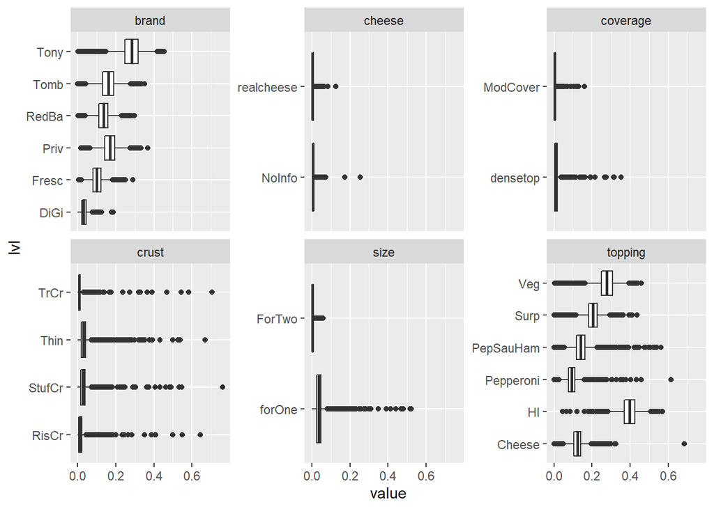

```r
out_pizza_screening_cal %>% ec_boxplot_screen()
```

### Comparisons

Side-by-side part-worths of the volumetric demand models

```r
  list(compensatory=out_pizza_cal,
       conjunctive =out_pizza_screening_cal) %>%
      map_dfr(ec_estimates_MU,.id='model') %>%
      select(model, attribute, lvl, par, mean) %>%
      pivot_wider(names_from = model, values_from = mean)
```

```
## # A tibble: 20 x 5
##    attribute lvl        par               compensatory conjunctive
##    <chr>     <chr>      <chr>                    <dbl>       <dbl>
##  1 <NA>      <NA>       int                   -2.79        -2.17
##  2 brand     Fresc      brand:Fresc           -0.351       -0.167
##  3 brand     Priv       brand:Priv            -0.686       -0.472
##  4 brand     RedBa      brand:RedBa           -0.603       -0.404
##  5 brand     Tomb       brand:Tomb            -0.664       -0.480
##  6 brand     Tony       brand:Tony            -1.05        -0.693
##  7 size      ForTwo     size:ForTwo            0.605        0.679
##  8 crust     StufCr     crust:StufCr          -0.142       -0.140
##  9 crust     Thin       crust:Thin            -0.102       -0.0559
## 10 crust     TrCr       crust:TrCr             0.00902      0.0354
## 11 topping   HI         topping:HI            -0.628        0.0639
## 12 topping   Pepperoni  topping:Pepperoni      0.208        0.276
## 13 topping   PepSauHam  topping:PepSauHam      0.153        0.336
## 14 topping   Surp       topping:Surp          -0.0123       0.297
## 15 topping   Veg        topping:Veg           -0.655       -0.319
## 16 coverage  ModCover   coverage:ModCover     -0.0540      -0.0764
## 17 cheese    realcheese cheese:realcheese      0.120        0.126
## 18 <NA>      <NA>       sigma                 -0.255       -0.0881
## 19 <NA>      <NA>       gamma                 -0.460       -0.0444
## 20 <NA>      <NA>       E                      3.61         3.46
```

## Demand Curves

### Define base case

```r
testm_pizza =
tibble(
  id=1L,task=1L,alt=1:6,
  brand= c("DiGi", "Fresc", "Priv", "RedBa", "Tomb", "Tony"),
  size= "forOne",
  crust="Thin",
  topping="Veg",
  coverage="ModCover",
  cheese="NoInfo",
  p=c(3.5,3,2,2,2,1.5)
) %>%   prep_newprediction(pizza_long)


testmarket=
tibble(
  id = rep(seq_len(n_distinct(pizza_long$id)),each=nrow(testm_pizza)),
  task = 1,
  alt = rep(1:nrow(testm_pizza),n_distinct(pizza_long$id))) %>%
  bind_cols(
    testm_pizza[rep(1:nrow(testm_pizza),n_distinct(pizza_long$id)),-(1:3)]
  )

focal_alternatives =
  testmarket %>% transmute(focal=brand=='Priv') %>% pull(focal)
```

### Obtain demand curve for focal brand

```r
#pre-sim error terms
eps_not <- testmarket %>% ec_gen_err_normal(out_pizza_cal_, 55667)


#demand curve compensatory
vd_demc_comp =
  testmarket %>%
    ec_demcurve(focal_alternatives,
                seq(0.5,1.5,,9),
                vd_dem_vdmn,
                out_pizza_cal_,
                eps_not)
```

```
##  Computation in progress
##  Computation in progress
##  Computation in progress
##  Computation in progress
##  Computation in progress
##  Computation in progress
##  Computation in progress
##  Computation in progress
##  Computation in progress
```

```r
#demand curve conjunctive screening
vd_demc_screenpr =
  testmarket %>%
    ec_demcurve(focal_alternatives,
                seq(0.5,1.5,,9),
                vd_dem_vdmsrpr,
                out_pizza_screening_cal_,
                eps_not)
```

```
##  Computation in progress
##  Computation in progress
##  Computation in progress
##  Computation in progress
##  Computation in progress
##  Computation in progress
##  Computation in progress
##  Computation in progress
##  Computation in progress
```

```r
#combine demand curves from both models
vd_outputs=rbind(
  vd_demc_comp %>% do.call('rbind',.) %>% bind_cols(model='comp') %>% bind_cols(demand='volumetric'),
  vd_demc_screenpr %>% do.call('rbind',.) %>% bind_cols(model='screenpr') %>% bind_cols(demand='volumetric'))
```

Plotting demand curves:

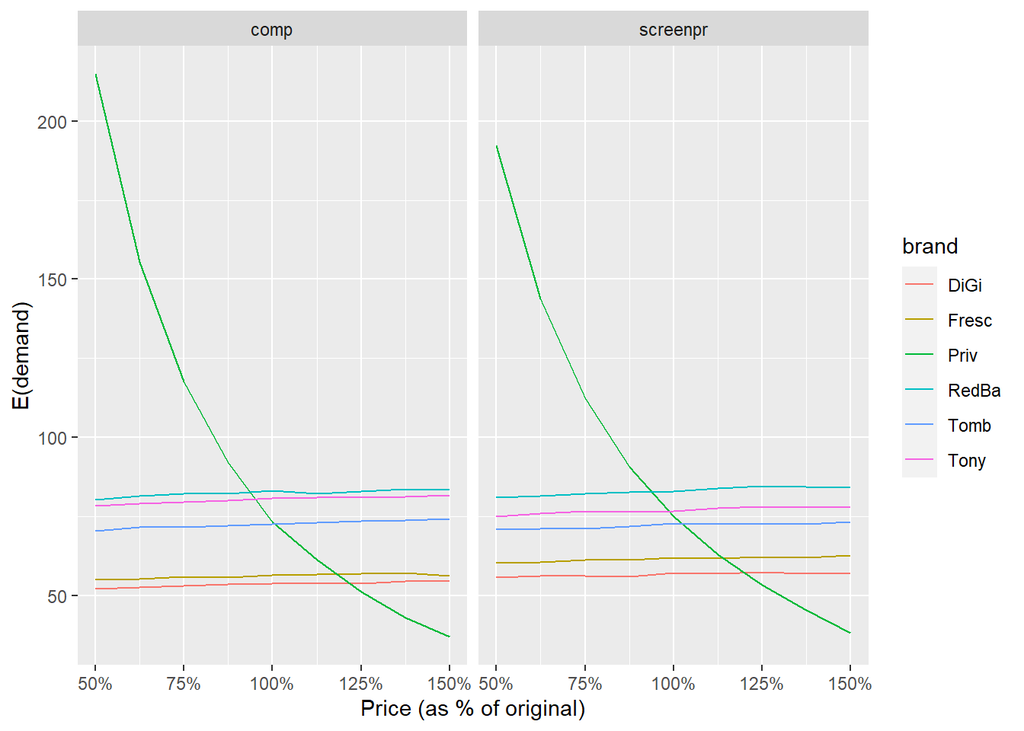

```r
  vd_outputs%>%
    ggplot(aes(x=scenario, y=`E(demand)`, color=brand)) + geom_line() + facet_wrap(~model)+
      xlab("Price (as % of original)") + scale_x_continuous(labels = scales::percent_format(), n.breaks = 5)
```

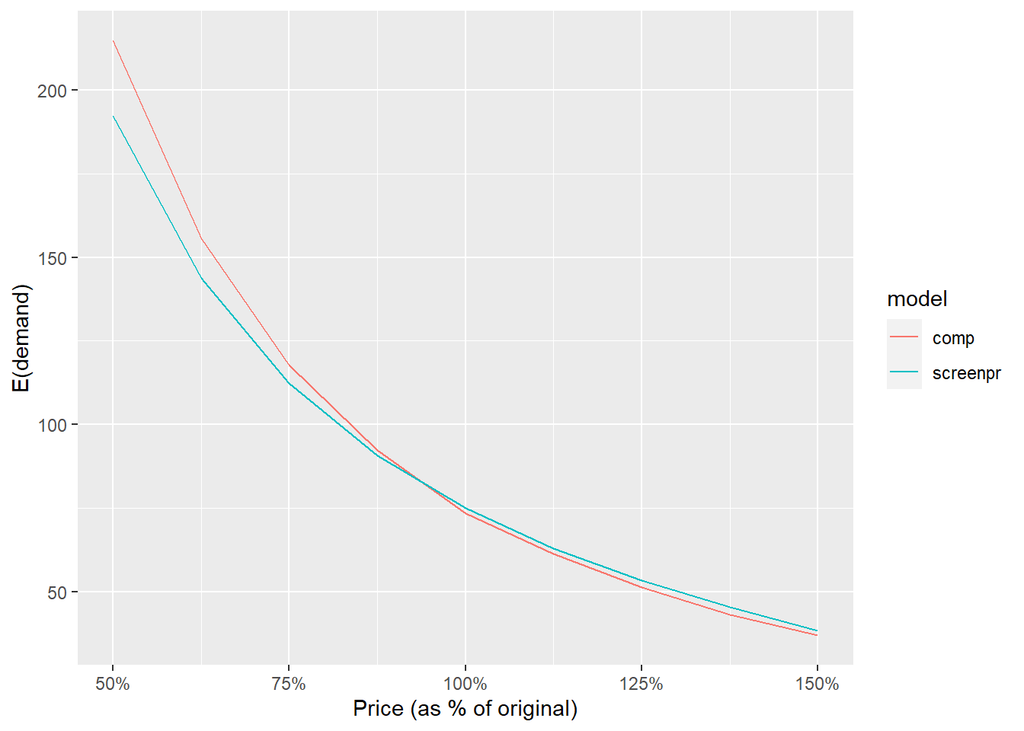

```r
  vd_outputs%>%
  filter(brand=="Priv") %>%
    ggplot(aes(x=scenario, y=`E(demand)`, color=model)) + geom_line() +
      xlab("Price (as % of original)") + scale_x_continuous(labels = scales::percent_format(), n.breaks = 5)
```

### Incidence curves

While demand curves look similar, incidence curves reveal that drastic price decreases lead to a smaller increase in people buying when accounting for screening:

```r
#demand curve compensatory
vd_demc_comp_inci =
  testmarket %>%
    ec_demcurve_inci(focal_alternatives,
                      seq(0.25,1.5,,9),
                      vd_dem_vdmn,
                      out_pizza_cal_,
                      eps_not)
```

```
##  Computation in progress
##  Computation in progress
##  Computation in progress
##  Computation in progress
##  Computation in progress
##  Computation in progress
##  Computation in progress
##  Computation in progress
##  Computation in progress
```

```r
#demand curve conjunctive screening
vd_demc_screenpr_inci =
  testmarket %>%
    ec_demcurve_inci(focal_alternatives,
                      seq(0.25,1.5,,9),
                      vd_dem_vdmsrpr,
                      out_pizza_screening_cal_,
                      eps_not)
```

```
##  Computation in progress
##  Computation in progress
##  Computation in progress
##  Computation in progress
##  Computation in progress
##  Computation in progress
##  Computation in progress
##  Computation in progress
##  Computation in progress
```

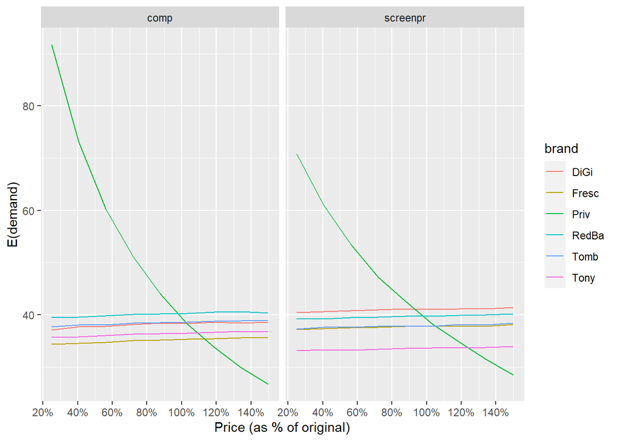

```r
#combine demand curves from both models
vd_outputs_inci=rbind(
  vd_demc_comp_inci %>% do.call('rbind',.) %>% bind_cols(model='comp') %>% bind_cols(demand='volumetric'),
  vd_demc_screenpr_inci %>% do.call('rbind',.) %>% bind_cols(model='screenpr') %>% bind_cols(demand='volumetric'))

 vd_outputs_inci%>%
    ggplot(aes(x=scenario, y=`E(demand)`, color=brand)) + geom_line() + facet_wrap(~model)+
      xlab("Price (as % of original)") + scale_x_continuous(labels = scales::percent_format(), n.breaks = 9)
```